# Regla de Bayes

Ejercicio 1

➢Se tiene dos cajas de bolígrafos. La primera contiene 23 bolígrafos azules y 17 rojos, y la segunda contiene 18 azules y 5 rojos.

a) ¿Cuál es la probabilidad de obtener un bolígrafo azul?

b) Si el bolígrafo que se obtuvo es rojo, ¿Cuál es la probabilidad de que haya sido obtenido de la caja 2?

Ejercicio 2

En la academia de MateMovil, la probabilidad de que a un alumno seleccionado al azar le guste el helado es del 60 %, mientras que la probabilidad de que a un alumno le guste la torta es del 36 %. Además, se sabe que la probabilidad de que a un alumno le guste la torta dado que le gusta el helado es del 40 %. Calcular la probabilidad de que a un alumno le guste el helado, dado que le gusta la torta.

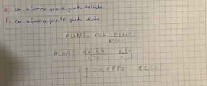

# Calculadora

Primera Comprobacion

Ai/B

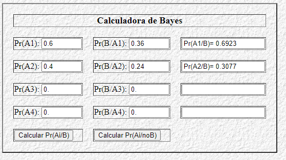

Ai/noB

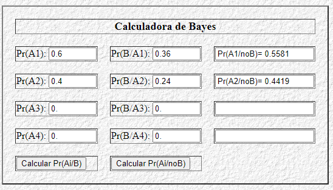

Segunda Comprobacion

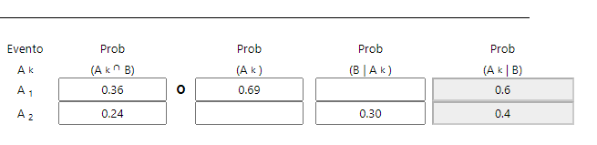

```python
# Probabilidad Bayes
def regla_bayes(a, p, b):
# regla P(n)
    n = 1 - a
# regla P(b)
    p_b = p * a + b * n
# regla P(a|b)
    g = (p * a) / p_b
    return g
# P(a)
a = 0.6
# P(b|a)
p = 0.36
# P(b|n)
b = 0.24
# regla P(a|b)
comprobacion = regla_bayes(a, p, b)
#Realizamos la respectiva sumarizacion
print('P(a|b) = %.6f%%' % (comprobacion))
```

```
P(a|b) = 0.692308%
```

```python
#Realizado por Christian Hernandez
```